# index

2024-12-04

## Exploring threat overlap between woodland caribou and other ‘species at risk’ in Canada

Read in and clean data

```r
# Read in dataset
threats <-read.csv('SAR_overlap_threats_NE_species_input_final_3.csv')

# Clean dataset
# Replace spaces with underscores in the taxonomic_group column
all_species_threats <- threats %>%
  mutate(taxonomic_group = gsub(" ", "_", taxonomic_group))

# Replace spaces with underscores in the common name column
all_species_threats <- all_species_threats %>%
  mutate(common_name = gsub(" ", "_", common_name))

# Keep only the most recent year_published for each common_name
all_species_threats <- all_species_threats %>%
  group_by(common_name) %>%
  filter(year_published == max(year_published)) %>%
  ungroup()

# Delete caribou that aren't relevant
all_species_threats <- all_species_threats %>%
  filter(!(common_name %in% c("caribou_dolphin_and_union_population", "peary_caribou")))

# To make a consistent data set replace any 2 values with a 1
all_species_threats_no2 <- all_species_threats %>%
  mutate(across(everything(), ~ ifelse(. == 2, 1, .)))

# Delete multiples of the same species that weren't eliminated with the process above
# Keep the row with the greatest number of threats listed per species
# To do this first count the number of traits (sum of 1s across trait columns)
all_species_threats_no2$X1_res_comm_development <- as.numeric(all_species_threats_no2$X1_res_comm_development)

# Convert non-numeric values in trait columns to NA
all_species_threats_no2 <- all_species_threats_no2 %>%
  mutate(trait_count = rowSums(select(., 16:70)))

# Keep only the row with the highest number of traits per species
all_species_threats_no2 <- all_species_threats_no2 %>%
  group_by(common_name) %>%
  slice_max(trait_count, n = 1) %>%  # Keeps row with highest trait count
  ungroup()

# delete row 88 as this is the exception to this
all_species_threats_no2 <- all_species_threats_no2 %>%
  filter(!(rowID %in% c("2094")))

# Delete all rows if not threats are recorded
all_species_threats_no2 <- all_species_threats_no2 %>%
  filter(trait_count != "0")

# Note that I considered deleting marine mammals, marine fish, marine molluscs and reptiles
# But these groups were deleted anyway as they didn't overlap in range with woodland caribou.

## Create row for combined mountain, boreal, eastern migratory and Torgat mountain, Atlantic Gaspesie caribou, Newfoundland threats
caribous <- all_species_threats_no2 %>% filter(rowID %in% c(256,264,2136,2137,2162,2163,2167))

write.csv(caribous, "caribous.csv")

# Extract columns 1-14 from row 264 (keep as a single row)
boreal_row_start <- caribous %>% filter(rowID == 264) %>% select(1:15)

# Extract columns 71-76 from row 264 (keep as a single row) -> will need to be updated with woodland caribou area values
boreal_row_end <- caribous %>% filter(rowID == 264) %>% select(71:76)

# Apply the OR operation across rows for columns 15-40 (ie if there is a 1 in the boreal or the mountain rows then in = 1)
or_values <- apply(caribous[, 16:70], 2, function(x) as.numeric(any(x == 1)))

# Combine the copied columns (1-14) and the new calculated columns (15-40)
caribou_row <- cbind(boreal_row_start, as.data.frame(t(or_values)))
caribou_row2<- cbind(caribou_row, boreal_row_end)

# Change woodland caribou specific information
caribou_row2$common_name <- "woodland caribou"
caribou_row2$web_pub_date <- "NA"
caribou_row2$year_published <- "NA"
caribou_row2$date_last_access <- "NA"
caribou_row2$Percent_SAR_caribou <- "100"
caribou_row2$Percent_caribou_SAR <- "100"
caribou_row2$Total_area_km <- "4325842.66"
caribou_row2$Intersect_caribou_km <- "4325842.66"
caribou_row2$year_published <- as.integer(caribou_row2$year_published)
# Bind to existing data set
all_species_threats_no2 <- bind_rows(all_species_threats_no2, caribou_row2)

# Delete boreal and mountain caribou rows
all_species_threats_no2 <- all_species_threats_no2 %>%
  filter(!(common_name %in% c("woodland_caribou_northern_mountain_population", "woodland_caribou_southern_mountain_population", "caribou_boreal_population",
                              "caribou_atlantic-gaspesie_population","eastern_migratory_caribou","torgat_mountain", 'caribou_newfoundland_population')))
```

## Make subsets for later use

```r
## Now make subsets!
# Make a data set with just species that overlap in range with caribou so filter rows where percent_caribou > 0
overlap_species_threats_no2 <- all_species_threats_no2 %>%
  filter(Percent_SAR_caribou > 0)

## Create subset of overlap data set using threat subcategories, and excluding overarching categories (that would be correlated with the sub categories)
subset_data <- overlap_species_threats_no2 %>% select(17,18,19,21,22,23,24,26,27,28,30,31,32,33,35,36,37,38,40,41,42,44,45,46,                                                     48,49,50,51,52,53,55,56,57,58,59,60,62,63,64,66,67,68,69,70)

## Convert all columns to factors
subset_data <- subset_data %>% mutate(across(everything(), as.numeric))

## Create subset using all over arching categories and subcategories
subset_data_large <- overlap_species_threats_no2 %>% select(16,17,18,19,20,21,22,23,24,25,26,27,29,30,31,33,32,34,35,36,37,38,39,40,42,41,43,44,45,46,47,                                                              48,49,50,51,52,53,54,55,56,57,58,59,60,61,62,63,64,65,66,67,68,69,70)
## Convert all columns to factors
subset_data_large <- subset_data_large %>% mutate(across(everything(), as.numeric))

## Create subset with just overarching categories
subset_data_over <- overlap_species_threats_no2 %>% select(16,20,25,29,34,39,43,47,54,61,65)

all_species_threats_no2$Total_area_km[all_species_threats_no2$Total_area_km == "#N/A"] <- NA
all_species_threats_no2$Intersect_caribou_km[all_species_threats_no2$Intersect_caribou_km == "#N/A"] <- NA
all_species_threats_no2$Percent_SAR_caribou[all_species_threats_no2$Percent_SAR_caribou == "#N/A"] <- NA
all_species_threats_no2$Percent_caribou_SAR[all_species_threats_no2$Percent_caribou_SAR == "#N/A"] <- NA

non_na_count <- sum(!is.na(all_species_threats_no2$Total_area_km))

## Find out how many row have species range overlap with caribou values of >20
all_species_threats_no2$Percent_SAR_caribou <- as.integer(all_species_threats_no2$Percent_SAR_caribou)
ex0 <- all_species_threats_no2 %>%
  filter(.[[73]] > 0) %>% nrow

ex20 <- all_species_threats_no2 %>%
  filter(.[[73]] > 20) %>% nrow

## Find out how many species we have range data for
exall <- all_species_threats_no2 %>%
filter(.[[72]] > 0) %>% nrow

#Find out how many species we have Ebar data for
exebar <- all_species_threats_no2 %>% filter(.[[75]] == 'Ebar') %>% nrow
```

## Calculate the Jaccard Index

Compute similarity between boreal caribou and other SAR in their IUCN threats using the Jaccard index.

```r
library(vegan)

# First compute for all data columns (overarching and subcategories)
dist <-vegdist(subset_data_large, method = "jaccard")

dist_matrix <- as.matrix(dist) # Convert dist object to a matrix
dist_df <- as.data.frame(dist_matrix) # Convert matrix to a data frame
row_97 <- dist_df[97, ] # Extract row 42 from dist_df
similarity_matrix <- 1 - dist_matrix # Make similarity matrix
sim_df <- as.data.frame(similarity_matrix) # Convert matrix to a data frame
row_97_sim <- sim_df[97, ] # Extract row 97 from similarity matrix

# Add row_97 as a column to overlap_caribou_threats_single
overlap_species_threats_no2 <- overlap_species_threats_no2 %>%
  mutate(row_97 = as.numeric(row_97))
# Add row_42_sim as a column to overlap_caribou_threats_single
overlap_species_threats_no2 <- overlap_species_threats_no2 %>%
  mutate(row_97_sim = as.numeric(row_97_sim))

## Next Create jaccard index for subset of just sub categories
dist_sub_cat <-vegdist(subset_data, method = "jaccard")
dist_matrix_cat <- as.matrix(dist_sub_cat) # Convert dist object to a matrix
dist_df_cat <- as.data.frame(dist_matrix_cat)
row_97_cat <- dist_df_cat[97, ]

# Make similarity matrix
similarity_matrix_cat <- 1 - dist_matrix_cat
sim_df_cat <- as.data.frame(similarity_matrix_cat)
row_97_sim_cat <- sim_df_cat[97, ]

# Add rows as a column to overlap_caribou_threats_single
overlap_species_threats_no2 <- overlap_species_threats_no2 %>%
  mutate(row_97_cat = as.numeric(row_97_cat))
overlap_species_threats_no2 <- overlap_species_threats_no2 %>%
  mutate(row_97_sim_cat = as.numeric(row_97_sim_cat))

###### Then next create jaccard index for subset of just overarching categories
dist_over_cat <-vegdist(subset_data_over, method = "jaccard")

# Convert dist object to a matrix
dist_matrix_over <- as.matrix(dist_over_cat)
dist_df_over <- as.data.frame(dist_matrix_over)
row_97_over <- dist_df_over[97, ]

# Make similarity matrix
similarity_matrix_over <- 1 - dist_matrix_over
sim_df_over <- as.data.frame(similarity_matrix_over)
row_97_sim_over <- sim_df_over[97, ]

# Add rows as a column to overlap_caribou_threats_single
overlap_species_threats_no2 <- overlap_species_threats_no2 %>%
  mutate(row_97_over = as.numeric(row_97_over))
overlap_species_threats_no2 <- overlap_species_threats_no2 %>%
  mutate(row_97_sim_over = as.numeric(row_97_sim_over))
```

## Find species at risk with highest and lowest Jaccard index scores

```r
# Filter dataset for rows with similarity >0.48 to find ten most similar
jaccard_0.63 <- overlap_species_threats_no2 %>%
  filter(row_97_sim > 0.63)

# find 10ish species most dissimilar
jaccard_0.30 <- overlap_species_threats_no2 %>%
  filter(row_97_sim < 0.28)

comparison <- jaccard_0.63 %>%
  bind_rows(jaccard_0.30) %>%
  bind_rows(caribou_row2)

write.csv(comparison, "comparison_jaccard.csv")
```

How many columns overlap? Look at the number of column in common between caribou and all other species in the dataset. These haven’t been used in later modelling but they could be..

```r
# Make some other more interesting variables (vertebrate/invertebrate, aquatic/terrestrial)
# Create a new column based on conditions
overlap_species_threats_no2 <- overlap_species_threats_no2 %>%
  mutate(T_group = case_when(
    taxonomic_group %in% c("Mammals_(terrestrial)", "Reptiles", "Amphibians","Birds" ) ~ "vertebrate",  # If category is A or B, assign 1
    taxonomic_group %in% c("Molluscs", "Arthropods") ~ "invertebrate" ,
    taxonomic_group %in% c("Lichens", "Vascular_Plants", "Mosses") ~ "plant" ,# If category is C or D, assign 2
  ))

overlap_species_threats_no2 <- overlap_species_threats_no2 %>%
  mutate(T_group = case_when(
    taxonomic_group %in% c("Mammals_(terrestrial)", "Reptiles", "Amphibians","Birds" ) ~ "aquatic",  # If category is A or B, assign 1
    taxonomic_group %in% c("Molluscs", "Arthropods") ~ "land" ,
    taxonomic_group %in% c("Lichens", "Vascular_Plants", "Mosses") ~ "plant" , # If category is C or D, assign 2
  ))

all_species_threats_no2 <- all_species_threats_no2 %>%
  mutate(Percent_SAR_caribou = as.numeric(Percent_SAR_caribou),
         Percent_caribou_SAR = as.numeric(Percent_caribou_SAR),
         Total_area_km = as.numeric(Total_area_km))

all_species_threats_no2 <- all_species_threats_no2 %>%
  mutate(Total_area_km = as.numeric(Total_area_km))
```

These aren’t used in later modelling but could be..

```r
## Try to compute similarity between species and woodland caribou row by looking at the number of columns in common between
## caribou and species that overlap in range with caribou

# First, extract the row corresponding to "caribou". Choose all columns (overarching and subcategories)
woodland_caribou_row <- overlap_species_threats_no2 %>%
  filter(common_name == "woodland caribou") %>%
  select(c(16,17,18,19,20,21,22,23,24,25,26,27,29,30,31,33,32,34,35,36,37,38,39,40,42,41,43,44,45,46,47,
           48,49,50,51,52,53,54,55,56,57,58,59,60,61,62,63,64,65,66,67,68,69,70))

# Create dataset to compare with
species_all_row <- overlap_species_threats_no2 %>%
  select(c(16,17,18,19,20,21,22,23,24,25,26,27,29,30,31,33,32,34,35,36,37,38,39,40,42,41,43,44,45,46,47,
           48,49,50,51,52,53,54,55,56,57,58,59,60,61,62,63,64,65,66,67,68,69,70))

# Create a new dataset comparing "caribou" to all other rows (and count 1's)
comparison <- species_all_row %>%
  rowwise() %>%
  mutate(matching_ones = sum(woodland_caribou_row == 1 & c_across(everything()) == 1, na.rm = TRUE)) %>%
  ungroup()

# Add common_columns column (!) to overlap_species_threats_no2
matching_ones <- comparison$matching_ones
overlap_species_threats_no2 <- overlap_species_threats_no2 %>%
  mutate(matching_ones = as.numeric(matching_ones))
```

## Run MCA to visualize differences based on taxonomic group

```
## Too few points to calculate an ellipse
```

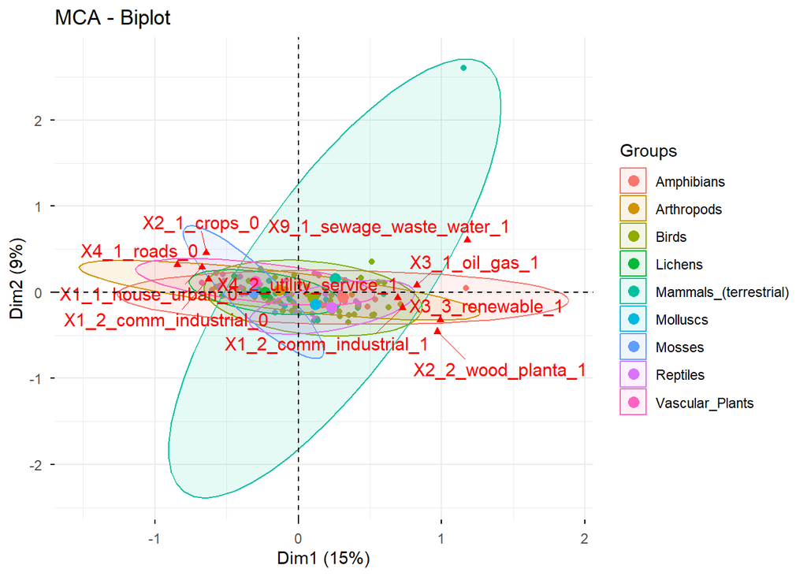

```r
# Load libraries
library(FactoMineR)
library(factoextra)

# Load dataset
subset_data_MCA<- overlap_species_threats_no2 %>% select(c(12,17,18,19,21,22,23,24,26,27,28,30,31,32,33,35,36,37,38,40,41,42,44,45,46,
                                                           48,49,50,51,52,53,55,56,57,58,59,60,62,63,64,66,67,68,69,70))
# Select taxonomic group and trait columns
taxonomic_col <- "taxonomic_group"  # Adjust based on actual column name
trait_cols <- setdiff(names(subset_data_MCA), taxonomic_col)  # Assuming all other columns are traits

# Convert taxonomic group to a factor
subset_data_MCA[[taxonomic_col]] <- as.factor(subset_data_MCA[[taxonomic_col]])

# Convert trait columns to factors (since MCA requires categorical data)
subset_data_MCA[trait_cols] <- lapply(subset_data_MCA[trait_cols], as.factor)

# Run MCA (excluding the taxonomic group initially)
mca_result <- MCA(subset_data_MCA[, trait_cols], graph = FALSE)

# Get the contribution scores for variables
trait_contrib <- data.frame(mca_result$var$contrib)

# Select the top 10 most influential traits (modify as needed)
top_traits <- rownames(trait_contrib)[order(-trait_contrib$Dim.1)[1:10]]

# Plot MCA biplot with only the most influential traits labeled
fviz_mca_biplot(mca_result,
                label = "var",  # Show variable names
                select.var = list(name = top_traits),  # Show only top traits
                habillage = subset_data_MCA[[taxonomic_col]],  # Color by taxonomic group
                addEllipses = TRUE,
                repel = TRUE)
```

```
## Too few points to calculate an ellipse
```

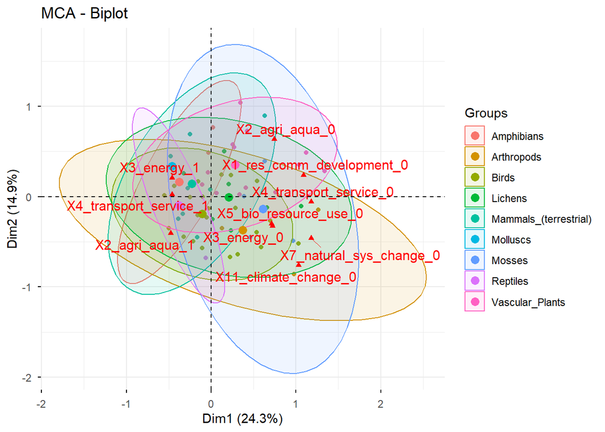

```r
### might be struggling with lots of zeros and sparse data from some columns


## Try with just overarching categories
# Load dataset
subset_data_MCA2<- overlap_species_threats_no2 %>% select(c(12,16,20,25,29,34,39,43,47,54,61,65))

# Select taxonomic group and trait columns
taxonomic_col3 <- "taxonomic_group"  # Adjust based on actual column name
trait_cols3 <- setdiff(names(subset_data_MCA2), taxonomic_col3)  # Assuming all other columns are traits

# Convert taxonomic group to a factor
subset_data_MCA2[[taxonomic_col3]] <- as.factor(subset_data_MCA2[[taxonomic_col3]])

# Convert trait columns to factors (since MCA requires categorical data)
subset_data_MCA2[trait_cols3] <- lapply(subset_data_MCA2[trait_cols3], as.factor)

# Run MCA (excluding the taxonomic group initially)
mca_result <- MCA(subset_data_MCA2[, trait_cols3], graph = FALSE)

# Get the contribution scores for variables
trait_contrib <- data.frame(mca_result$var$contrib)

# Select the top 10 most influential traits (modify as needed)
top_traits <- rownames(trait_contrib)[order(-trait_contrib$Dim.1)[1:10]]

# Plot MCA biplot with only the most influential traits labeled
fviz_mca_biplot(mca_result,
                label = "var",  # Show variable names
                select.var = list(name = top_traits),  # Show only top traits
                habillage = subset_data_MCA2[[taxonomic_col3]],  # Color by taxonomic group
                addEllipses = TRUE,
                repel = TRUE)
```

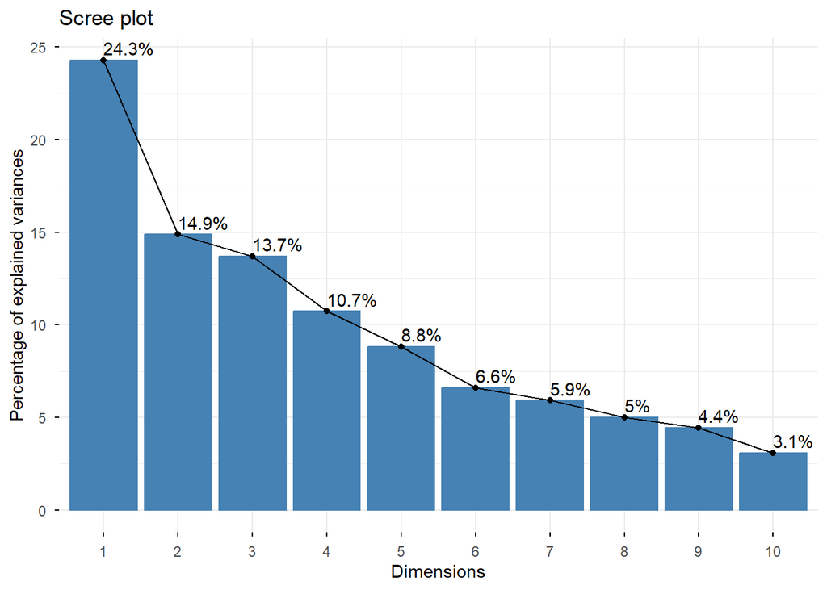

```r
fviz_screeplot(mca_result, addlabels = TRUE)
```

## Check for correlations prior to running models

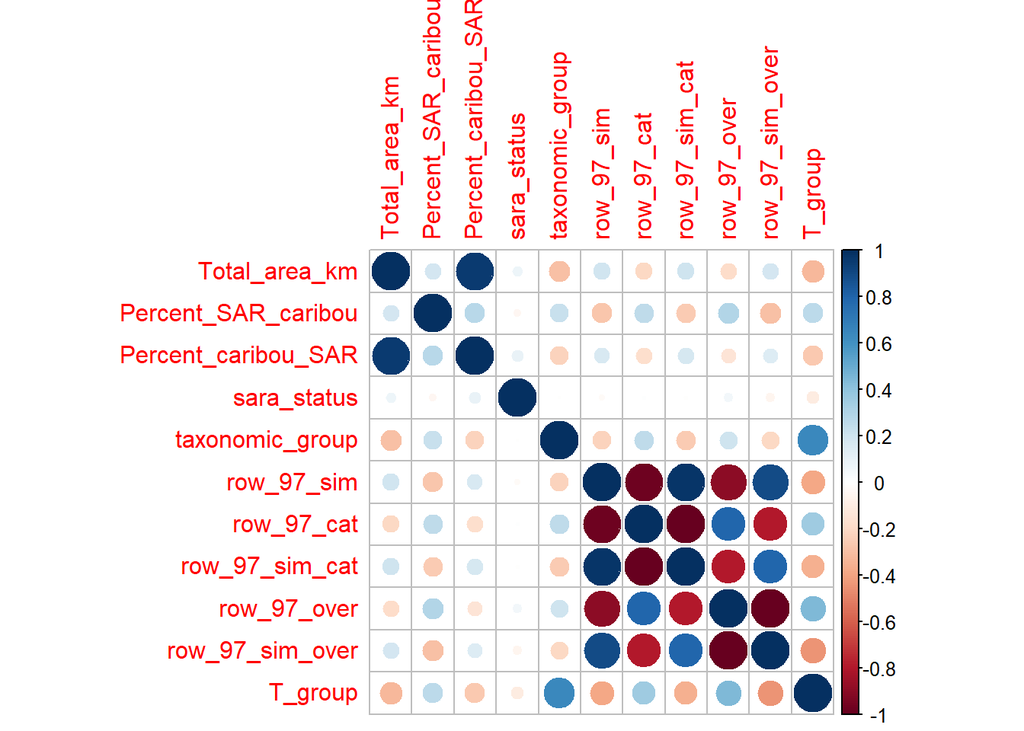

```r
model_subset <- overlap_species_threats_no2 %>% select(72,73,74,6,12,78,79,80,81,82,83,84)

numeric_vars <- model_subset %>%
  select(Total_area_km, Percent_SAR_caribou, Percent_caribou_SAR, sara_status, taxonomic_group, row_97_sim, row_97_cat, row_97_sim_cat, row_97_over,row_97_sim_over, T_group) %>%
  mutate(
  sara_status = as.numeric(as.factor(sara_status)),  # Convert factors to numeric
  taxonomic_group = as.numeric(as.factor(taxonomic_group)),
  T_group = as.numeric(as.factor(T_group)),
  Total_area_km = as.numeric(Total_area_km),
  Percent_SAR_caribou = as.numeric(Percent_SAR_caribou),
  Percent_caribou_SAR = as.numeric(Percent_caribou_SAR))

correlation_matrix <- cor(numeric_vars, use = "complete.obs")  # Use complete.obs to handle NAs
corrplot(correlation_matrix, method="circle")
```

```r
# Print the correlation matrix
print(correlation_matrix)
```

```
##                     Total_area_km Percent_SAR_caribou Percent_caribou_SAR
## Total_area_km          1.00000000          0.18050141          0.95864352
## Percent_SAR_caribou    0.18050141          1.00000000          0.27856721
## Percent_caribou_SAR    0.95864352          0.27856721          1.00000000
## sara_status            0.07328077         -0.04176513          0.09462841
## taxonomic_group       -0.29136135          0.22777934         -0.22702900
## row_97_sim             0.19206452         -0.27791376          0.16525423
## row_97_cat            -0.20192611          0.25076107         -0.17862578
## row_97_sim_cat         0.20192611         -0.25076107          0.17862578
## row_97_over           -0.18354435          0.29951709         -0.14455284
## row_97_sim_over        0.18354435         -0.29951709          0.14455284
## T_group               -0.32699639          0.26604807         -0.26174803
##                      sara_status taxonomic_group  row_97_sim   row_97_cat
## Total_area_km        0.073280769    -0.291361347  0.19206452 -0.201926112
## Percent_SAR_caribou -0.041765126     0.227779342 -0.27791376  0.250761071
## Percent_caribou_SAR  0.094628409    -0.227029004  0.16525423 -0.178625777
## sara_status          1.000000000    -0.005083689 -0.02874618  0.009922701
## taxonomic_group     -0.005083689     1.000000000 -0.22557096  0.251135627
## row_97_sim          -0.028746183    -0.225570965  1.00000000 -0.975531828
## row_97_cat           0.009922701     0.251135627 -0.97553183  1.000000000
## row_97_sim_cat      -0.009922701    -0.251135627  0.97553183 -1.000000000
## row_97_over          0.053944838     0.204269677 -0.89585571  0.790499273
## row_97_sim_over     -0.053944838    -0.204269677  0.89585571 -0.790499273
## T_group             -0.104203865     0.647515567 -0.38879111  0.356380841
##                     row_97_sim_cat row_97_over row_97_sim_over    T_group
## Total_area_km          0.201926112 -0.18354435      0.18354435 -0.3269964
## Percent_SAR_caribou   -0.250761071  0.29951709     -0.29951709  0.2660481
## Percent_caribou_SAR    0.178625777 -0.14455284      0.14455284 -0.2617480
## sara_status           -0.009922701  0.05394484     -0.05394484 -0.1042039
## taxonomic_group       -0.251135627  0.20426968     -0.20426968  0.6475156
## row_97_sim             0.975531828 -0.89585571      0.89585571 -0.3887911
## row_97_cat            -1.000000000  0.79049927     -0.79049927  0.3563808
## row_97_sim_cat         1.000000000 -0.79049927      0.79049927 -0.3563808
## row_97_over           -0.790499273  1.00000000     -1.00000000  0.4409453
## row_97_sim_over        0.790499273 -1.00000000      1.00000000 -0.4409453
## T_group               -0.356380841  0.44094533     -0.44094533  1.0000000
```

## Model correlates of threat overlap with caribou

Run a beta regression model that examine drivers of overlap in threats (Jaccard index) with caribou. These predictors include species range area (Total_area_km), percentage range overlap with caribou (Percent_caribou) and taxonomic group (taxonomic_group_1 etc).

```r
# Run some models looking at descriptors of threat overlap with caribou

overlap_species_threats_no2 <- overlap_species_threats_no2 %>%
  mutate(
    sara_status = as.factor(sara_status),
    taxonomic_group = as.factor(taxonomic_group),
    Percent_SAR_caribou = as.numeric(Percent_SAR_caribou),
    Total_area_km = as.numeric(Total_area_km)
  )

# First delete row 97 (woodland caribou)
overlap_species_threats_no2 <- overlap_species_threats_no2 %>%
  filter(speciesID!=54)

# Make reference level for the variable taxonomic group
overlap_species_threats_no2$taxonomic_group <- factor(overlap_species_threats_no2$taxonomic_group, levels = c("Molluscs", "Arthropods", "Birds", "Lichens", "Amphibians","Mammals_(terrestrial)", "Mosses", "Reptiles", "Vascular_Plants"))
overlap_species_threats_no2$taxonomic_group <- relevel(overlap_species_threats_no2$taxonomic_group, ref = "Birds")

# Try betareg
# First transform be response variables so they're not close to 0 or 1
overlap_species_threats_no2 <- overlap_species_threats_no2 %>%
  mutate(Trans_row_97_sim = (overlap_species_threats_no2$row_97_sim * (nrow(overlap_species_threats_no2) - 1) + 0.5)/(nrow(overlap_species_threats_no2)))

be1 <- betareg(Trans_row_97_sim ~ scale(Percent_SAR_caribou), data=overlap_species_threats_no2, link = "logit")
be2 <- betareg(Trans_row_97_sim ~ scale(log(Total_area_km)), data=overlap_species_threats_no2, link = "logit")
be3 <- betareg(Trans_row_97_sim ~ taxonomic_group, data=overlap_species_threats_no2, link = "logit")
be4 <- betareg(Trans_row_97_sim ~ 1, data=overlap_species_threats_no2, link = "logit")
be5 <- betareg(Trans_row_97_sim ~ scale(Percent_SAR_caribou) + scale(log(Total_area_km)) + taxonomic_group,data=overlap_species_threats_no2, link = "logit")

fmList4<-model.sel(be1=be1, be2=be2, be3=be3, be4=be4, be5=be5)
fmList4
```

```
## Model selection table
##        (Int) scl(Prc_SAR_crb) scl(log(Ttl_are_km)) txn_grp df logLik  AICc
## be5 -0.23190         -0.04608               0.2207       + 12 56.273 -85.3
## be3 -0.07919                                             + 10 52.974 -83.7
## be2 -0.07502                                0.2240          3 31.082 -55.9
## be1 -0.07349         -0.16990                               3 29.166 -52.1
## be4 -0.07420                                                2 26.471 -48.8
##     delta weight
## be5  0.00  0.689
## be3  1.59  0.311
## be2 29.36  0.000
## be1 33.19  0.000
## be4 36.47  0.000
## Models ranked by AICc(x)
```

```r
summary(be5)
```

```
##
## Call:
## betareg(formula = Trans_row_97_sim ~ scale(Percent_SAR_caribou) + scale(log(Total_area_km)) +
##     taxonomic_group, data = overlap_species_threats_no2, link = "logit")
##
## Quantile residuals:
##     Min      1Q  Median      3Q     Max
## -3.5328 -0.7216  0.1390  0.4987  2.9963
##
## Coefficients (mean model with logit link):
##                                       Estimate Std. Error z value Pr(>|z|)
## (Intercept)                          -0.231864   0.115468  -2.008  0.04464 *
## scale(Percent_SAR_caribou)           -0.046083   0.068303  -0.675  0.49987
## scale(log(Total_area_km))             0.220702   0.093574   2.359  0.01835 *
## taxonomic_groupMolluscs               1.065476   0.410506   2.596  0.00944 **
## taxonomic_groupArthropods            -0.446712   0.242830  -1.840  0.06583 .
## taxonomic_groupLichens               -0.058861   0.265474  -0.222  0.82453
## taxonomic_groupAmphibians             1.533241   0.277420   5.527 3.26e-08 ***
## taxonomic_groupMammals_(terrestrial)  0.139272   0.226258   0.616  0.53819
## taxonomic_groupMosses                -0.107653   0.379520  -0.284  0.77667
## taxonomic_groupReptiles               0.514664   0.265240   1.940  0.05233 .
## taxonomic_groupVascular_Plants       -0.003229   0.227516  -0.014  0.98868
##
## Phi coefficients (precision model with identity link):
##       Estimate Std. Error z value Pr(>|z|)
## (phi)    9.711      1.258   7.719 1.17e-14 ***
## ---
## Signif. codes:  0 '***' 0.001 '**' 0.01 '*' 0.05 '.' 0.1 ' ' 1
##
## Type of estimator: ML (maximum likelihood)
## Log-likelihood: 56.27 on 12 Df
## Pseudo R-squared: 0.3557
## Number of iterations: 22 (BFGS) + 2 (Fisher scoring)
```

```r
vif(be5)
```

```
##                                GVIF Df GVIF^(1/(2*Df))
## scale(Percent_SAR_caribou) 1.269017  1        1.126506
## scale(log(Total_area_km))  2.392727  1        1.546844
## taxonomic_group            2.651112  8        1.062831
```

## Check model fit

Look at residuals vs fitted and QQ plots

```r
# Residuals vs Fitted plot
p1 <- ggplot(data = NULL, aes(x = fitted(be5), y = residuals(be5))) +
  geom_point() +
  geom_hline(yintercept = 0, color = "red") +
  labs(title = "Residuals vs Fitted", x = "Fitted values", y = "Residuals") +
    theme(
    axis.title.y = element_text(margin = margin(t = 0, r = 30, b = 0, l = 0)),
    panel.background = element_rect(fill = 'white', colour = 'darkgrey'),
    panel.grid.major = element_line(colour = 'white'),
    text = element_text(size = 10),  # Increase overall font size
    axis.title = element_text(size = 10),  # Axis titles
    axis.text = element_text(size = 10))  # Axis text

# Q-Q plot
p2 <- ggplot(data = NULL, aes(sample = residuals(be5))) +
  stat_qq() +
  stat_qq_line(color = "blue") +
  labs(title = "Normal Q-Q Plot") +
    theme(
    axis.title.y = element_text(margin = margin(t = 0, r = 30, b = 0, l = 0)),
    panel.background = element_rect(fill = 'white', colour = 'darkgrey'),
    panel.grid.major = element_line(colour = 'white'),
    text = element_text(size = 10),  # Increase overall font size
    axis.title = element_text(size = 10),  # Axis titles
    axis.text = element_text(size = 10))  # Axis text

# Save plots as one figure
jpeg("./plots/F1I.jpeg",  width = 6000, height = 3000, res = 600)
grid.arrange(p1, p2, ncol = 2)
dev.off()
```

```r
fitted_vals <- fitted(be5)
resid_vals <- residuals(be5)
model_outputs <- overlap_species_threats_no2 %>%
  select(rowID) %>%  # Select only the join key
  mutate(
    fitted = fitted_vals,
    residual = resid_vals
  )
joined_data <- overlap_species_threats_no2 %>%
  left_join(model_outputs, by = "rowID")
joined_data <- joined_data %>%
  select(1,3,85,86,87)
```

## Plot coefficient estimates of best fitting model

Currently this is the estimates of be5

```r
# Plot model averaged coefficient estimates of best fitting model
# Extract coefficients and standard errors from the model

# Get  summary object
sum_be5 <- summary(be5)

# Extract coefficients for the mean model
coef_table <- coef(sum_be5)$mean

# Turn into a data frame
coefficients_df <- as.data.frame(coef_table)
coefficients_df$Variable <- rownames(coef_table)
rownames(coefficients_df) <- NULL

# Add confidence intervals

coefficients_df <- coefficients_df %>%
  mutate(
    Lower = Estimate - 1.96 * `Std. Error`,
    Upper = Estimate + 1.96 * `Std. Error`)

# Rename categories
comp3 <- coefficients_df %>%
  mutate(Variable = as.character(Variable)) %>%
  mutate(Variable = dplyr::recode(Variable,
                         "taxonomic_groupArthropods" = "Arthropods",
                         "taxonomic_groupBirds" = "Birds",
                         "taxonomic_groupLichens" = "Lichens",
                         "taxonomic_groupAmphibians" = "Amphibians",
                         "taxonomic_groupMammals_(terrestrial)" = "Mammals",
                         "taxonomic_groupReptiles" = "Reptiles",
                         "taxonomic_groupVascular_Plants" = "Vascular plants",
                         "taxonomic_groupMolluscs" = "Molluscs",
                         "taxonomic_groupMosses" = "Mosses",
                         "scale(log(Total_area_km))" = "Total range area",
                         "scale(Percent_SAR_caribou)" = "Percentage range overlap",
                          "(Intercept)"="Intercept"))


# Specify the desired order of categories
desired_order5 <- c("Amphibians",
                    "Molluscs",
                    "Reptiles",
                    "Mammals",
                    "Vascular plants",
                    "Lichens",
                    "Birds",
                    "Mosses",
                    "Arthropods",
                    "Total range area",
                    "Percentage range overlap",
                    "Intercept")

# Reorder the factor levels in the data frame
comp3$Variable <- factor(comp3$Variable, levels = desired_order5)

coef_all <- ggplot(comp3,aes(x=Variable,y=Estimate)) +
  geom_hline(yintercept = 0, col = "darkgrey") +  # Horizontal line at y = 0
  geom_point() +
  geom_errorbar(aes(ymin=Lower,ymax=Upper)) +
  coord_flip() +
  labs(x= "Variable", y= "Coefficent estimate") +
  theme(
    axis.title.y = element_text(margin = margin(t = 0, r = 30, b = 0, l = 0)),
    panel.background = element_rect(fill = 'white', colour = 'darkgrey'),
    panel.grid.major = element_line(colour = 'white'),
    text = element_text(size = 10),  # Increase overall font size
    axis.title = element_text(size = 10),  # Axis titles
    axis.text = element_text(size = 10))  # Axis text

# Save the plot (pdf)
ggsave(
  filename = "./plots/coef_all.pdf",
  plot = coef_all,
  device = "pdf",   height = 10, width = 17,
  units = "cm")
# Save the plot (jpeg)
ggsave(
  filename = "./plots/coef_all.jpg",
  plot = coef_all,
  device = "jpg",   height = 10, width = 17,
  units = "cm")
```

## (no outliers) Model correlates of threat overlap with caribou

Check if model outputs are the same without outliers!

```r
# Run some models looking at descriptors of threat overlap with caribou

# Delete outliers!!!
overlap_species_threats_no2 <- overlap_species_threats_no2 %>%
  filter(!speciesID %in% c('1502', '88', '431'))

# Make reference level for the variable taxonomic group
overlap_species_threats_no2$taxonomic_group <- factor(overlap_species_threats_no2$taxonomic_group, levels = c("Molluscs", "Arthropods", "Birds", "Lichens", "Amphibians","Mammals_(terrestrial)", "Mosses", "Reptiles", "Vascular_Plants"))
overlap_species_threats_no2$taxonomic_group <- relevel(overlap_species_threats_no2$taxonomic_group, ref = "Birds")

be1o <- betareg(Trans_row_97_sim ~ scale(Percent_SAR_caribou), data=overlap_species_threats_no2, link = "logit")
be2o <- betareg(Trans_row_97_sim ~ scale(log(Total_area_km)), data=overlap_species_threats_no2, link = "logit")
be3o <- betareg(Trans_row_97_sim ~ taxonomic_group, data=overlap_species_threats_no2, link = "logit")
be4o <- betareg(Trans_row_97_sim ~ 1, data=overlap_species_threats_no2, link = "logit")
be5o <- betareg(Trans_row_97_sim ~ scale(Percent_SAR_caribou) + scale(log(Total_area_km)) + taxonomic_group,data=overlap_species_threats_no2, link = "logit")

fmList5o<-model.sel(be1o=be1o, be2o=be2o, be3o=be3o, be4o=be4o, be5o=be5o)
fmList5o
```

```
## Model selection table
##         (Int) scl(Prc_SAR_crb) scl(log(Ttl_are_km)) txn_grp df logLik   AICc
## be5o -0.17820          -0.1118               0.1220       + 12 69.548 -111.7
## be3o -0.08186                                             + 10 65.891 -109.5
## be1o -0.16500          -0.2218                               3 54.183 -102.1
## be2o -0.16500                                0.1711          3 51.278  -96.3
## be4o -0.16390                                                2 47.287  -90.5
##      delta weight
## be5o  0.00  0.752
## be3o  2.28  0.241
## be1o  9.61  0.006
## be2o 15.42  0.000
## be4o 21.28  0.000
## Models ranked by AICc(x)
```

```r
summary(be5o)
```

```
##
## Call:
## betareg(formula = Trans_row_97_sim ~ scale(Percent_SAR_caribou) + scale(log(Total_area_km)) +
##     taxonomic_group, data = overlap_species_threats_no2, link = "logit")
##
## Quantile residuals:
##     Min      1Q  Median      3Q     Max
## -2.5047 -0.5188  0.1876  0.6091  2.6571
##
## Coefficients (mean model with logit link):
##                                      Estimate Std. Error z value Pr(>|z|)
## (Intercept)                          -0.17821    0.09853  -1.809  0.07048 .
## scale(Percent_SAR_caribou)           -0.11180    0.05904  -1.894  0.05829 .
## scale(log(Total_area_km))             0.12196    0.08052   1.515  0.12987
## taxonomic_groupMolluscs               0.89926    0.34950   2.573  0.01008 *
## taxonomic_groupArthropods            -0.45616    0.20642  -2.210  0.02711 *
## taxonomic_groupLichens               -0.20041    0.22579  -0.888  0.37475
## taxonomic_groupAmphibians             0.72151    0.26299   2.743  0.00608 **
## taxonomic_groupMammals_(terrestrial)  0.13735    0.19179   0.716  0.47391
## taxonomic_groupMosses                -0.26856    0.32350  -0.830  0.40644
## taxonomic_groupReptiles               0.42426    0.22524   1.884  0.05962 .
## taxonomic_groupVascular_Plants       -0.14270    0.19318  -0.739  0.46010
##
## Phi coefficients (precision model with identity link):
##       Estimate Std. Error z value Pr(>|z|)
## (phi)   13.944      1.853   7.525 5.28e-14 ***
## ---
## Signif. codes:  0 '***' 0.001 '**' 0.01 '*' 0.05 '.' 0.1 ' ' 1
##
## Type of estimator: ML (maximum likelihood)
## Log-likelihood: 69.55 on 12 Df
## Pseudo R-squared: 0.3405
## Number of iterations: 20 (BFGS) + 2 (Fisher scoring)
```

```r
vif(be5o)
```

```
##                                GVIF Df GVIF^(1/(2*Df))
## scale(Percent_SAR_caribou) 1.276818  1        1.129964
## scale(log(Total_area_km))  2.401640  1        1.549723
## taxonomic_group            2.631055  8        1.062327
```

## (no outliers) Check model fit

Look at residuals vs fitted and QQ plots

```r
# Residuals vs Fitted plot
p1 <- ggplot(data = NULL, aes(x = fitted(be5o), y = residuals(be5o))) +
  geom_point() +
  geom_hline(yintercept = 0, color = "red") +
  labs(title = "a.) Residuals vs Fitted", x = "Fitted values", y = "Residuals") +
    theme(
    axis.title.y = element_text(margin = margin(t = 0, r = 30, b = 0, l = 0)),
    panel.background = element_rect(fill = 'white', colour = 'darkgrey'),
    panel.grid.major = element_line(colour = 'white'),
    text = element_text(size = 6),  # Increase overall font size
    axis.title = element_text(size = 6),  # Axis titles
    axis.text = element_text(size = 6))  # Axis text

# Q-Q plot
p2 <- ggplot(data = NULL, aes(sample = residuals(be5o))) +
  stat_qq() +
  stat_qq_line(color = "blue") +
  labs(title = "b.) Normal Q-Q Plot") +
    theme(
    axis.title.y = element_text(margin = margin(t = 0, r = 30, b = 0, l = 0)),
    panel.background = element_rect(fill = 'white', colour = 'darkgrey'),
    panel.grid.major = element_line(colour = 'white'),
    text = element_text(size = 6),  # Increase overall font size
    axis.title = element_text(size = 6),  # Axis titles
    axis.text = element_text(size = 6))  # Axis text

# Save plots as one figure
jpeg("./plots/F1Io.jpeg",  width = 6000, height = 3000, res = 600)
grid.arrange(p1, p2, ncol = 2)
dev.off()
```

## (no outliers) Plot coefficient estimates of best fitting model (no outliers)

Currently this is the estimates of be5

```r
# Plot model averaged coefficient estimates of best fitting model
# Extract coefficients and standard errors from the model

# Get summary object
sum_be5o <- summary(be5o)

# Extract coefficients for the mean model
coef_table <- coef(sum_be5o)$mean

# Turn into a data frame
coefficients_df <- as.data.frame(coef_table)
coefficients_df$Variable <- rownames(coef_table)
rownames(coefficients_df) <- NULL

# Add confidence intervals

coefficients_df <- coefficients_df %>%
  mutate(
    Lower = Estimate - 1.96 * `Std. Error`,
    Upper = Estimate + 1.96 * `Std. Error`)

# Rename categories
comp3 <- coefficients_df %>%
  mutate(Variable = as.character(Variable)) %>%
  mutate(Variable = dplyr::recode(Variable,
                         "taxonomic_groupArthropods" = "Arthropods",
                         "taxonomic_groupBirds" = "Birds",
                         "taxonomic_groupLichens" = "Lichens",
                         "taxonomic_groupAmphibians" = "Amphibians",
                         "taxonomic_groupMammals_(terrestrial)" = "Mammals",
                         "taxonomic_groupReptiles" = "Reptiles",
                         "taxonomic_groupVascular_Plants" = "Vascular plants",
                         "taxonomic_groupMolluscs" = "Molluscs",
                         "taxonomic_groupMosses" = "Mosses",
                         "scale(log(Total_area_km))" = "Total range area",
                         "scale(Percent_SAR_caribou)" = "Percentage range overlap",
                          "(Intercept)"="Intercept"))


# Specify the desired order of categories
desired_order5 <- c("Amphibians",
                    "Molluscs",
                    "Reptiles",
                    "Mammals",
                    "Vascular plants",
                    "Lichens",
                    "Birds",
                    "Mosses",
                    "Arthropods",
                    "Total range area",
                    "Percentage range overlap",
                    "Intercept")

# Reorder the factor levels in the data frame
comp3$Variable <- factor(comp3$Variable, levels = desired_order5)

coef_allo <- ggplot(comp3,aes(x=Variable,y=Estimate)) +
  geom_hline(yintercept = 0, col = "darkgrey") +  # Horizontal line at y = 0
  geom_point() +
  geom_errorbar(aes(ymin=Lower,ymax=Upper)) +
  coord_flip() +
  labs(x= "Variable", y= "Coefficent estimate") +
  labs(title = "c.) Coefficent estimates") +
  theme(
    axis.title.y = element_text(margin = margin(t = 0, r = 30, b = 0, l = 0)),
    panel.background = element_rect(fill = 'white', colour = 'darkgrey'),
    panel.grid.major = element_line(colour = 'white'),
    text = element_text(size = 6),  # Increase overall font size
    axis.title = element_text(size = 6),  # Axis titles
    axis.text = element_text(size = 6))  # Axis text

# Save the plot (pdf)
ggsave(
  filename = "./plots/coef_allo.pdf",
  plot = coef_allo,
  device = "pdf",   height = 10, width = 17,
  units = "cm")
# Save the plot (jpeg)
ggsave(
  filename = "./plots/coef_allo.jpg",
  plot = coef_allo,
  device = "jpg",   height = 10, width = 17,
  units = "cm")

# Save plots as one figure
jpeg("./plots/allo.jpeg",  width = 5000, height = 3000, res = 600)
grid.arrange(p1, p2, coef_allo, ncol = 2)
dev.off()
```

## Plot shared percentage of all possible threat columns and percentage of threat colums shared with caribou

```r
shared_1s <- overlap_species_threats_no2 %>% select(3,12,18,19,21,22,23,26,27,30,31,35,37,40,42, 44,46,49,55,56,59,60,64,66,68,69)
shared_1s <- shared_1s %>%
  mutate(sum = rowSums(across(where(is.numeric), ~ . == 1)))
shared_1s <- shared_1s %>%
  mutate(percent = (sum/24)*100)

shared_1s_long <- shared_1s %>%
  group_by(taxonomic_group) %>%
  summarise(
    avg_percentage = mean(percent, na.rm = TRUE),
    n = sum(!is.na(percent)),
    sd = sd(percent, na.rm = TRUE),
    se = sd / sqrt(n),
    ci_lower = avg_percentage - 1.96 * se,
    ci_upper = avg_percentage + 1.96 * se
  )
shared_1s_long <- shared_1s_long %>%
  mutate(group = "Threats shared with caribou")

all_1s <- overlap_species_threats_no2 %>% select(3,12,17,18,19,21,22,23,24,26,27,28,30,31,32,33,35,36,37,38,40,41,42,44,45,46,                                               48,49,50,51,52,53,55,56,57,58,59,60,62,63,64,66,67,68,69,70)
all_1s <- all_1s %>%
  mutate(sum = rowSums(across(where(is.numeric), ~ . == 1)))
all_1s <- all_1s %>%
  mutate(percent = (sum/44)*100)
shared_alls_long <- all_1s %>%
  group_by(taxonomic_group) %>%
  summarise(
    avg_percentage = mean(percent, na.rm = TRUE),
    n = sum(!is.na(percent)),
    sd = sd(percent, na.rm = TRUE),
    se = sd / sqrt(n),
    ci_lower = avg_percentage - 1.96 * se,
    ci_upper = avg_percentage + 1.96 * se
  )
shared_alls_long <- shared_alls_long %>%
  mutate(group = "All threats")

both_1s<-rbind(shared_alls_long, shared_1s_long)
both_1s <- both_1s %>%
  mutate(taxonomic_group = as.character(taxonomic_group)) %>%
  mutate(taxonomic_group = dplyr::recode(taxonomic_group,
                                         "Mammals_(terrestrial)" = "Mammals",
                                         "Vascular_Plants" = "Vascular plants"))

# Specify the desired order of categories
desired_order8 <- c("Molluscs",
                    "Amphibians",
                    "Mammals",
                    "Reptiles",
                    "Birds",
                    "Vascular plants",
                    "Lichens",
                    "Arthropods",
                    "Mosses")

# Reorder the factor levels in the data frame
both_1s$taxonomic_group <- factor(both_1s$taxonomic_group, levels = desired_order8)

both1 <- ggplot(both_1s, aes(x = taxonomic_group, y = avg_percentage, color = group)) +
  geom_point(position = position_dodge(width = 0.5), size = 3) +
  geom_errorbar(aes(ymin = ci_lower, ymax = ci_upper),
                position = position_dodge(width = 0.5), width = 0.2) +
  labs(x = "Taxonomic group", y = "Average percentage threats",
       color = "Group") +
  scale_color_manual(values = c("darkblue", "cyan3")) +
  theme_minimal() +
  theme(axis.text.x = element_text(angle = 45, hjust = 1),
        text = element_text(size = 10),  # Increase overall font size
        axis.title = element_text(size = 10),  # Axis titles
        axis.text = element_text(size = 10),
        legend.text = element_text(size = 10))  # Axis text)

# Save the plot
ggsave(
  filename = "./plots/both1.pdf",
  plot = both1,
  device = "pdf",   height = 10, width = 17,
  units = "cm")

ggsave(
  filename = "./plots/both1.jpg",
  plot = both1,
  device = "jpg",   height = 10, width = 17,
  units = "cm")
```

## Plot SAR taxonomic group and caribou range overlap

Make a graph that shows which taxonomic groups of SAR overlap most with caribou ranges

```r
# take all rows we have spatial data for
summary_data_overlap_start <- all_species_threats_no2 %>%
  filter(Total_area_km >0)

# Calculate the number of species of the 461 we have spatial data for with overlap values of >0
ex2 <- summary_data_overlap_start %>%
  filter(.[[73]] > 0) %>% nrow
ex3 <- summary_data_overlap_start %>%
  filter(.[[73]] > 20) %>% nrow
ex4 <- summary_data_overlap_start %>%
  filter(.[[73]] > 40) %>% nrow
ex6 <- summary_data_overlap_start %>%
  filter(.[[73]] > 60) %>% nrow
ex8 <- summary_data_overlap_start %>%
  filter(.[[73]] > 80) %>% nrow
ex2
```

```
## [1] 94
```

```r
ex3
```

```
## [1] 58
```

```r
ex4
```

```
## [1] 40
```

```r
ex6
```

```
## [1] 20
```

```r
ex8
```

```
## [1] 15
```

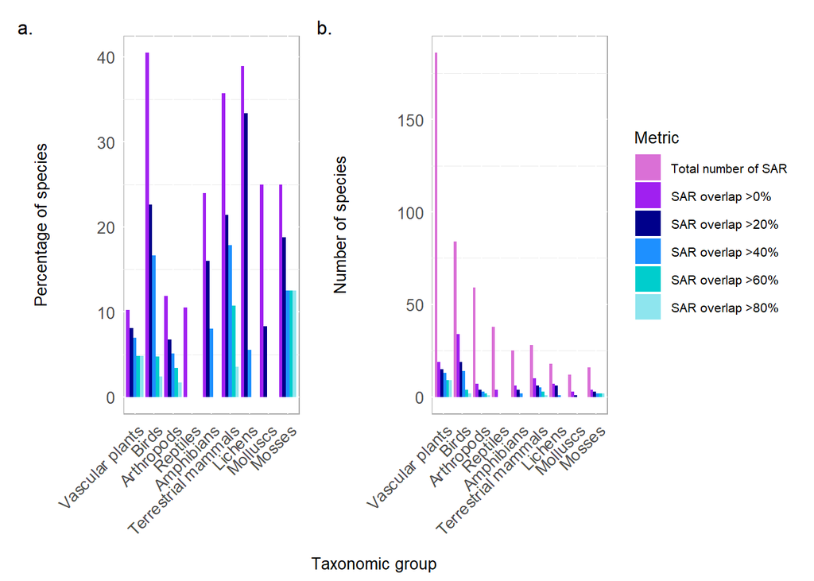

```r
summary_data_overlap_tax <- summary_data_overlap_start %>%
  group_by(taxonomic_group) %>%
  summarise(count = n())

# summarise the number and percent of SAR that exist and overlap with caribou
summary_data_overlap <- summary_data_overlap_start %>%
  group_by(taxonomic_group) %>%
  summarise(
    total_species = n(),
    overlap_nonzero = sum(Percent_SAR_caribou > 0, na.rm = TRUE),
    overlap_above_20 = sum(Percent_SAR_caribou > 20, na.rm = TRUE),
  overlap_above_40 = sum(Percent_SAR_caribou > 40, na.rm = TRUE),
  overlap_above_60 = sum(Percent_SAR_caribou > 60, na.rm = TRUE),
  overlap_above_80 = sum(Percent_SAR_caribou > 80, na.rm = TRUE)) %>%
  pivot_longer(cols = c(total_species, overlap_nonzero, overlap_above_20, overlap_above_40, overlap_above_60, overlap_above_80),
  names_to = "Category", values_to = "Count") %>%
  mutate(Percentage = case_when(
    taxonomic_group == "Amphibians" ~ (Count / 25) * 100,
    taxonomic_group == "Arthropods" ~ (Count / 59) * 100,
    taxonomic_group == "Birds" ~ (Count / 84) * 100,
    taxonomic_group == "Lichens" ~ (Count / 18) * 100,
    taxonomic_group == "Mammals_(terrestrial)" ~ (Count / 28) * 100,
    taxonomic_group == "Molluscs" ~ (Count / 12) * 100,
    taxonomic_group == "Mosses" ~ (Count / 16) * 100,
    taxonomic_group == "Reptiles" ~ (Count / 38) * 100,
    taxonomic_group == "Vascular_Plants" ~ (Count / 186) * 100,
    TRUE ~ NA_real_  # Default case (if needed)
  ))

summary_data_overlap <- summary_data_overlap %>%
  mutate(taxonomic_group = as.character(taxonomic_group)) %>%
  mutate(taxonomic_group = dplyr::recode(taxonomic_group, "Vascular_Plants" = "Vascular plants",))%>%
  mutate(taxonomic_group = dplyr::recode(taxonomic_group, "Mammals_(terrestrial)" = "Terrestrial mammals"))

# Specify the desired order of categories
desired_order4 <- c("Vascular plants", "Birds", "Arthropods", "Reptiles", "Amphibians", "Terrestrial mammals",
                    "Lichens", "Molluscs", "Mosses")

# Reorder the factor levels in the data frame
summary_data_overlap$taxonomic_group <- factor(summary_data_overlap$taxonomic_group, levels = desired_order4)# as no spatial data for

# Create grouped bar plot of number of species
summary_data_overlap_filtered <- summary_data_overlap %>%
  filter(Category != "total_species")

# Define category order
category_order <- c(
  "total_species",
  "overlap_nonzero",
  "overlap_above_20",
  "overlap_above_40",
  "overlap_above_60",
  "overlap_above_80")

summary_data_overlap$Category <- factor(
  summary_data_overlap$Category,
  levels = category_order)

summary_data_overlap_filtered$Category <- factor(
  summary_data_overlap_filtered$Category,
  levels = category_order)

# Plot number of species
count_species_taxonomic_group <- ggplot(summary_data_overlap_filtered, aes(x = taxonomic_group, y = Percentage, fill = Category)) +
  geom_bar(stat = "identity", position = "dodge") +
labs(
  x = NULL,
  y = "Percentage of species",
  fill = "Metric"
  ) +
  scale_fill_manual(values = c("purple","darkblue","dodgerblue","cyan3","cadetblue2"),
  guide = "none") +
  theme_minimal() +
  theme(
    legend.position = "none",
    axis.title.y = element_text(margin = margin(t = 0, r = 30, b = 0, l = 0)),
    axis.text.x = element_text(angle = 45, hjust = 1),
    panel.background = element_rect(fill = 'white', colour = 'darkgrey'),
    panel.grid.major = element_line(colour = 'white'),
    text = element_text(size = 10),  # Increase overall font size
    axis.title = element_text(size = 10),  # Axis titles
    axis.text = element_text(size = 10))

# Create grouped bar plot of number of species
count_species_taxonomic_group2 <- ggplot(summary_data_overlap, aes(x = taxonomic_group, y = Count, fill = Category)) +
  geom_bar(stat = "identity", position = "dodge") +
labs(
  x = NULL,
  y = "Number of species",
  fill = "Metric"
) +
  scale_fill_manual(values = c("orchid","purple","darkblue","dodgerblue","cyan3","cadetblue2"),
                    labels = c("Total number of SAR","SAR overlap >0%", "SAR overlap >20%", "SAR overlap >40%","SAR overlap >60%","SAR overlap >80%")) +
  theme_minimal() +
  theme(
    axis.title.y = element_text(margin = margin(t = 0, r = 30, b = 0, l = 0)),
    axis.text.x = element_text(angle = 45, hjust = 1),
    panel.background = element_rect(fill = 'white', colour = 'darkgrey'),
    panel.grid.major = element_line(colour = 'white'),
    text = element_text(size = 10),  # Increase overall font size
    axis.title = element_text(size = 10),  # Axis titles
    axis.text = element_text(size = 10))

combined_plot <- (count_species_taxonomic_group +
  count_species_taxonomic_group2 +
  plot_layout(ncol = 2, guides = "collect")) +
  plot_annotation(
    tag_levels = list(c("a.", "b.")),
    caption = "Taxonomic group"
  ) &
  theme(
    legend.position = "right",
    plot.caption = element_text(
      size = 10,
      hjust = 0.45,
    )
  )

combined_plot
```

```r
# Save the plot
ggsave(
  filename = "./plots/count_species_taxonomic_group_combined.pdf",
  plot = combined_plot,
  height = 10, width = 25,
  units = "cm")
ggsave(
  filename = "./plots/count_species_taxonomic_group_combined.jpg",
  plot = combined_plot,
  height = 10, width = 25,
  units = "cm")
```

## Graph the number of species with values of the jaccard index

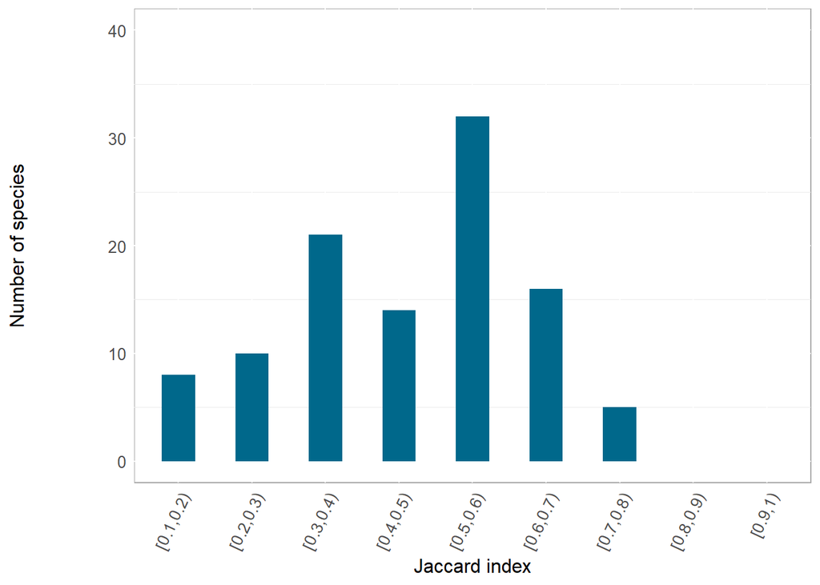

```r
# Summarize the number of values in each range
summary <- overlap_species_threats_no2 %>%
  mutate(bin = cut(row_97_sim, breaks = seq(0, 1, by = 0.1), right = FALSE)) %>%
  group_by(bin) %>%
  summarise(count = n(), .groups = "drop") %>%
  filter(!is.na(bin)) %>%
  bind_rows(
  tibble(
    bin = c("[0.7,0.8)","[0.8,0.9)", "[0.9,1)"),
    count = c(0, 0, 0)
  )
)

ggplot(summary, aes(x = bin, y = count, width=0.45)) +
  geom_bar(stat = "identity", fill = "deepskyblue4" ) +
  labs(x = "Jaccard index",
       y = "Number of species") +
  theme_minimal() +
  ylim(0, 40) +
  theme(
    axis.title.y = element_text(margin = margin(t = 0, r = 50, b = 0, l = 0)),
    axis.text.x = element_text(angle = 65, hjust = 1, margin = margin(t = 0, r = 0, b = 20, l = 0)),
    panel.background = element_rect(fill = 'white', colour = 'darkgrey'),
    panel.grid.major = element_line(colour = 'white'),
    text = element_text(size = 10),  # Increase overall font size
    axis.title = element_text(size = 12),  # Axis titles
    axis.text = element_text(size = 10),  # Axis text
    legend.position = "none"
  )
```

## Make a heatmap figure for overarching categories

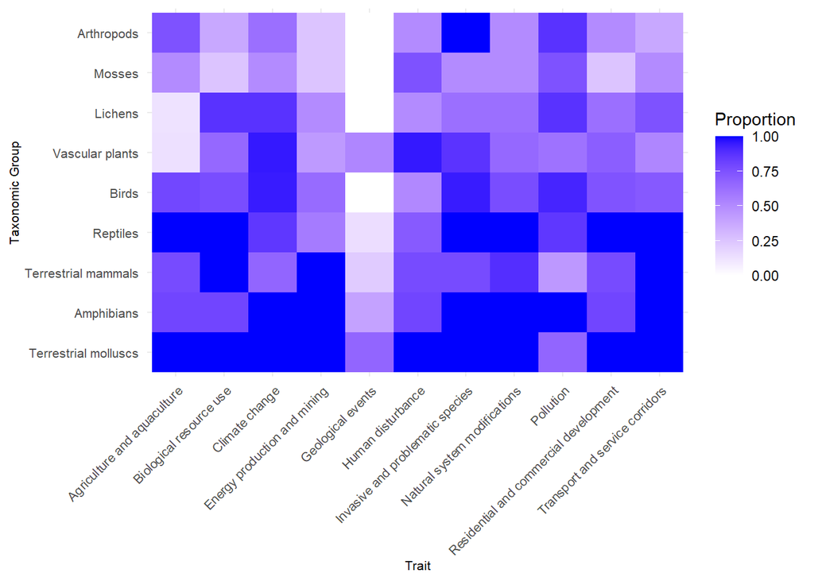

```r
heat <- overlap_species_threats_no2  # Replace with actual dataset
###Create subset with just overarching categories
heat_subset_data_over <- heat %>% select(12,16,20,25,29,34,39,43,47,54,61,65)
# Assuming the dataset has 'Taxonomic_Group' and binary trait columns
taxonomic_col <- "taxonomic_group"  # Adjust as needed
trait_cols <- setdiff(names(heat_subset_data_over), taxonomic_col)

# Convert to long format and calculate proportions
df_long <- heat_subset_data_over %>%
  pivot_longer(cols = all_of(trait_cols), names_to = "Trait", values_to = "Presence") %>%
  group_by(taxonomic_group, Trait) %>%
  summarise(Proportion = mean(Presence), .groups = "drop")

df_long <- df_long %>%
  mutate(Trait = dplyr::recode(Trait,
                                "X2_agri_aqua" = "Agriculture and aquaculture",
                                "X5_bio_resource_use" = "Biological resource use",
                                "X11_climate_change" = "Climate change",
                                "X3_energy" = "Energy production and mining",
                                "X10_geological_event" = "Geological events",
                                "X6_human_disturbance" = "Human disturbance",
                                "X8_invasive_species" = "Invasive and problematic species",
                                "X7_natural_sys_change" = "Natural system modifications",
                                "X9_pollution" = "Pollution",
                                "X1_res_comm_development" = "Residential and commercial development",
                                "X4_transport_service" = "Transport and service corridors"))

df_long <- df_long %>%
  mutate(taxonomic_group = as.character(taxonomic_group)) %>%
  mutate(taxonomic_group = dplyr::recode(taxonomic_group, "Vascular_Plants" = "Vascular plants",))%>%
  mutate(taxonomic_group = dplyr::recode(taxonomic_group, "Mammals_(terrestrial)" = "Terrestrial mammals"))%>%
  mutate(taxonomic_group = dplyr::recode(taxonomic_group, "Molluscs" = "Terrestrial molluscs"))

df_long <- df_long %>%
  mutate(taxonomic_group = fct_relevel(taxonomic_group, "Terrestrial molluscs", "Amphibians", "Terrestrial mammals", "Reptiles","Birds","Vascular plants", "Lichens","Mosses","Arthropods"))

ggplot(df_long, aes(x = Trait, y = taxonomic_group, fill = Proportion)) +
  geom_tile() +
  scale_fill_gradient(low = "white", high = "blue", name = "Proportion") +
  theme_minimal() +
  labs(x = "Trait", y = "Taxonomic Group") +
  theme(axis.text.x = element_text(angle = 45, hjust = 1, size = 8),
        axis.text.y = element_text(size = 8),
        axis.title = element_text(size = 8))# Axis titles
```

## Make a heatmap figure for sub categories

Including a heat map for those categories shard with caribou, and a seperate one for threats not shared.

```r
###### Make a heatmap figure for sub categories
# Load your dataset

heat2 <- overlap_species_threats_no2  # Replace with actual dataset
###Create subset with just sub categories of shared threats with caribou
heat_subset_data_over2 <- heat2 %>% select(12,18,19,21,22,23,26,27,30,31,35,37,40,42,44,46,
                                         49,55,56,59,60,64,66,68,69)
# Assuming the dataset has 'Taxonomic_Group' and binary trait columns
taxonomic_col2 <- "taxonomic_group"  # Adjust as needed
trait_cols2 <- setdiff(names(heat_subset_data_over2), taxonomic_col2)

# Convert to long format and calculate proportions
df_long2 <- heat_subset_data_over2 %>%
  pivot_longer(cols = all_of(trait_cols2), names_to = "Trait", values_to = "Presence") %>%
  group_by(taxonomic_group, Trait) %>%
  summarise(Proportion = mean(Presence), .groups = "drop")

df_long2 <- df_long2 %>%
  mutate(Trait = dplyr::recode(Trait,
                               "X10_1_volcano" = "10.1 Volcanic events",
                               "X10_2_earth_quake" = "10.2 Earthquake/tsunami events",
                               "X10_3_avalanche" = "10.3 Avalances/landside events",
                               "X11_1_hab_shift" = "11.1 Climate change caused habitat shifts",
                               "X11_2_drought" = "11.2 Climate change caused droughts",
                               "X11_3_temp_extreme" = "11.3 Climate change caused temperature extremes",
                               "X11_4_storm_flood" = "11.4 Climate change caused storms and flooding",
                               "X11_5_other_impacts" = "11.5 Other impacts of climate change",
                               "X1_1_house_urban" = "1.1 Housing and urban development",
                               "X1_2_comm_industrial" = "1.2 Commercial and industrial development",
                               "X1_3_tourisim_rec" = "1.3 Tourisim and recreational development",
                               "X2_1_crops" = "2.1 Annual and perennial crops",
                               "X2_2_wood_planta" = "2.2 Wood and pulp plantations",
                               "X2_3_livestock_farm" = "2.3 Livestock farming",
                               "X2_4_aqua" = "2.4 Marine and freshwater aquaculture",
                               "X3_1_oil_gas" = "3.1 Oil and gas drilling",
                               "X3_2_mining" = "3.2 Mining and quarrying",
                               "X3_3_renewable" = "3.3 Renewable energy development",
                               "X4_1_roads" = "4.1 Roads",
                               "X4_2_utility_service" = "4.2 Utility and service corridors",
                               "X4_3_shipping_lane" = "4.3 Shipping lanes",
                               "X4_4_flight_path" = "4.4 Flight paths",
                               "X5_1_hunting" = "5.1 Hunting and collection of terrestial animals",
                               "X5_2_gathering" = "5.2 Hunting and collection of terrestrial plants",
                               "X5_3_logging" = "5.3 Logging and wood harvesting",
                               "X5_4_fishing" = "5.4 Fishing and harvesting of aquatic resources",
                               "X6_1_recreation" = "6.1 Recreational activities",
                               "X6_2_war" = "6.2 War and civil unrest",
                               "X6_3_work_activity" = "6.3 Work activities",
                               "X7_1_fire_fire_sup" = "7.1 Fire and fire suppression",
                                "X7_2_dams_water" = "7.2 Dam and water management/use",
                                "X7_3_ecosysmod" = "7.3 Other ecosystem modifications",
                                "X8_1_invasive_nonative" = "8.1 Invasive species",
                                "X8_2_problematic_native" = "8.2 Problematic species",
                                "X8_3_introduced_genetic" = "8.3 Introduced genetic material",
                                "X8_4_problematic_species" = "8.4 Problematic species of unknown origin",
                                "X8_5_viral_disease" = "8.5 Viral induced diseases",
                               "X8_6_disease_unknown" = "8.6 Diseases of unknown cause",
                               "X9_1_sewage_waste_water" = "9.1 Domestic and urban waste water",
                               "X9_2_industrial_waste" = "9.2 Industrial and military effluents",
                               "X9_3_agricultural_waste" = "9.3 Agricultural and forestry effluents",
                               "X9_4_garbage_soil_waste" = "9.4 Garbage and solid waste",
                               "X9_5_air_boure_pollute" = "9.5 Air-bourne pollutants",
                               "X9_6_excess_energy" = "9.6 Excess energy"))


df_long2 <- df_long2 %>%
  mutate(taxonomic_group = as.character(taxonomic_group)) %>%
  mutate(taxonomic_group = dplyr::recode(taxonomic_group, "Vascular_Plants" = "Vascular plants",))%>%
  mutate(taxonomic_group = dplyr::recode(taxonomic_group, "Mammals_(terrestrial)" = "Terrestrial mammals"))%>%
  mutate(taxonomic_group = dplyr::recode(taxonomic_group, "Molluscs" = "Terrestrial molluscs"))

df_long2 <- df_long2 %>%
  mutate(taxonomic_group = fct_relevel(taxonomic_group, "Amphibians", "Terrestrial molluscs", "Reptiles", "Terrestrial mammals","Birds","Vascular plants", "Lichens","Mosses","Arthropods"))

# Specify the desired order of categories
desired_order6 <- c(
  "1.1 Housing and urban development",
  "1.2 Commercial and industrial development",
  "1.3 Tourisim and recreational development",
  "2.1 Annual and perennial crops",
  "2.2 Wood and pulp plantations",
  "2.3 Livestock farming",
  "2.4 Marine and freshwater aquaculture",
  "3.1 Oil and gas drilling",
  "3.2 Mining and quarrying",
  "3.3 Renewable energy development",
  "4.1 Roads",
  "4.2 Utility and service corridors",
  "4.3 Shipping lanes",
  "4.4 Flight paths",
  "5.1 Hunting and collection of terrestial animals",
  "5.2 Hunting and collection of terrestrial plants",
  "5.3 Logging and wood harvesting",
  "5.4 Fishing and harvesting of aquatic resources",
  "6.1 Recreational activities",
  "6.2 War and civil unrest",
  "6.3 Work activities",
  "7.1 Fire and fire suppression",
  "7.2 Dam and water management/use",
  "7.3 Other ecosystem modifications",
  "8.1 Invasive species",
  "8.2 Problematic species",
  "8.3 Introduced genetic material",
  "8.4 Problematic species of unknown origin",
  "8.5 Viral induced diseases",
  "8.6 Diseases of unknown cause",
  "9.1 Domestic and urban waste water",
  "9.2 Industrial and military effluents",
  "9.3 Agricultural and forestry effluents",
  "9.4 Garbage and solid waste",
  "9.5 Air-bourne pollutants",
  "9.6 Excess energy",
  "10.1 Volcanic events",
  "10.2 Earthquake/tsunami events",
  "10.3 Avalances/landside events",
  "11.1 Climate change caused habitat shifts",
  "11.2 Climate change caused droughts",
  "11.3 Climate change caused temperature extremes",
  "11.4 Climate change caused storms and flooding",
  "11.5 Other impacts of climate change")
```

```r
# Reorder the factor levels in the data frame
df_long2$Trait <- factor(df_long2$Trait, levels = desired_order6)

heat_caribou <- ggplot(df_long2, aes(x = Trait, y = taxonomic_group, fill = Proportion)) +
  geom_tile() +
  scale_fill_gradient(low = "white", high = "blue", name = "Proportion") +
  theme_minimal() +
  labs(x = "Threat", y = "Taxonomic Group") +
  theme(axis.text.x = element_text(angle = 45, hjust = 1, size = 8),
        axis.text.y = element_text(size = 8),
        axis.title = element_text(size = 8),
        legend.text = element_text(size = 7),
        legend.title = element_text(size = 8))

# Save the plot
ggsave(
  filename = "./plots/heat_caribou.pdf",
  plot = heat_caribou ,
  device = "pdf",   height = 10, width = 17,
  units = "cm")

#######################
### Make a heatmap for subcategories that don't overlap with caribou
heat3 <- overlap_species_threats_no2  # Replace with actual dataset
###Create subset with just sub categories of non-shared threats with caribou
heat_subset_data_over3 <- heat3 %>% select(12,17,24,32,33,36,38,41,48,45,50,51,52,53,57,58,62,63,67,70)
# Assuming the dataset has 'Taxonomic_Group' and binary trait columns
taxonomic_col3 <- "taxonomic_group"  # Adjust as needed
trait_cols3 <- setdiff(names(heat_subset_data_over3), taxonomic_col3)

# Convert to long format and calculate proportions
df_long3 <- heat_subset_data_over3 %>%
  pivot_longer(cols = all_of(trait_cols3), names_to = "Trait", values_to = "Presence") %>%
  group_by(taxonomic_group, Trait) %>%
  summarise(Proportion = mean(Presence), .groups = "drop")

df_long3 <- df_long3 %>%
  mutate(Trait = dplyr::recode(Trait,
                               "X10_1_volcano" = "10.1 Volcanic events",
                               "X10_2_earth_quake" = "10.2 Earthquake/tsunami events",
                               "X10_3_avalanche" = "10.3 Avalances/landside events",
                               "X11_1_hab_shift" = "11.1 Climate change caused habitat shifts",
                               "X11_2_drought" = "11.2 Climate change caused droughts",
                               "X11_3_temp_extreme" = "11.3 Climate change caused temperature extremes",
                               "X11_4_storm_flood" = "11.4 Climate change caused storms and flooding",
                               "X11_5_other_impacts" = "11.5 Other impacts of climate change",
                               "X1_1_house_urban" = "1.1 Housing and urban development",
                               "X1_2_comm_industrial" = "1.2 Commercial and industrial development",
                               "X1_3_tourisim_rec" = "1.2 Tourisim and recreational development",
                               "X2_1_crops" = "2.1 Annual and perennial crops",
                               "X2_2_wood_planta" = "2.2 Wood and pulp plantations",
                               "X2_3_livestock_farm" = "2.3 Livestock farming",
                               "X2_4_aqua" = "2.4 Marine and freshwater aquaculture",
                               "X3_1_oil_gas" = "3.1 Oil and gas drilling",
                               "X3_2_mining" = "3.2 Mining and quarrying",
                               "X3_3_renewable" = "3.3 Renewable energy development",
                               "X4_1_roads" = "4.1 Roads",
                               "X4_2_utility_service" = "4.2 Utility and service corridors",
                               "X4_3_shipping_lane" = "4.3 Shipping lanes",
                               "X4_4_flight_path" = "4.4 Flight paths",
                               "X5_1_hunting" = "5.1 Hunting and collection of terrestial animals",
                               "X5_2_gathering" = "5.2 Hunting and collection of terrestrial plants",
                               "X5_3_logging" = "5.3 Logging and wood harvesting",
                               "X5_4_fishing" = "5.4 Fishing and harvesting of aquatic resources",
                               "X6_1_recreation" = "6.1 Recreational activities",
                               "X6_2_war" = "6.2 War and civil unrest",
                               "X6_3_work_activity" = "6.3 Work activities",
                               "X7_1_fire_fire_sup" = "7.1 Fire and fire suppression",
                               "X7_2_dams_water" = "7.2 Dam and water management/use",
                               "X7_3_ecosysmod" = "7.3 Other ecosystem modifications",
                               "X8_1_invasive_nonative" = "8.1 Invasive species",
                               "X8_2_problematic_native" = "8.2 Problematic species",
                               "X8_3_introduced_genetic" = "8.3 Introduced genetic material",
                               "X8_4_problematic_species" = "8.4 Problematic species of unknown origin",
                               "X8_5_viral_disease" = "8.5 Viral induced diseases",
                               "X8_6_disease_unknown" = "8.6 Diseases of unknown cause",
                               "X9_1_sewage_waste_water" = "9.1 Domestic and urban waste water",
                               "X9_2_industrial_waste" = "9.2 Industrial and military effluents",
                               "X9_3_agricultural_waste" = "9.3 Agricultural and forestry effluents",
                               "X9_4_garbage_soil_waste" = "9.4 Garbage and solid waste",
                               "X9_5_air_boure_pollute" = "9.5 Air-bourne pollutants",
                               "X9_6_excess_energy" = "9.6 Excess energy"))


df_long3 <- df_long3 %>%
  mutate(taxonomic_group = as.character(taxonomic_group)) %>%
  mutate(taxonomic_group = dplyr::recode(taxonomic_group, "Vascular_Plants" = "Vascular plants",))%>%
  mutate(taxonomic_group = dplyr::recode(taxonomic_group, "Mammals_(terrestrial)" = "Terrestrial mammals"))%>%
  mutate(taxonomic_group = dplyr::recode(taxonomic_group, "Molluscs" = "Terrestrial molluscs"))

df_long3 <- df_long3 %>%
  mutate(taxonomic_group = fct_relevel(taxonomic_group, "Amphibians", "Terrestrial molluscs", "Reptiles", "Terrestrial mammals","Birds","Vascular plants", "Lichens","Mosses","Arthropods"))
```

```r
# Specify the desired order of categories
desired_order7 <- c(
  "1.1 Housing and urban development",
  "1.2 Commercial and industrial development",
  "1.2 Tourisim and recreational development",
  "2.1 Annual and perennial crops",
  "2.2 Wood and pulp plantations",
  "2.3 Livestock farming",
  "2.4 Marine and freshwater aquaculture",
  "3.1 Oil and gas drilling",
  "3.2 Mining and quarrying",
  "3.3 Renewable energy development",
  "4.1 Roads",
  "4.2 Utility and service corridors",
  "4.3 Shipping lanes",
  "4.4 Flight paths",
  "5.1 Hunting and collection of terrestial animals",
  "5.2 Hunting and collection of terrestrial plants",
  "5.3 Logging and wood harvesting",
  "5.4 Fishing and harvesting of aquatic resources",
  "6.1 Recreational activities",
  "6.2 War and civil unrest",
  "6.3 Work activities",
  "7.1 Fire and fire suppression",
  "7.2 Dam and water management/use",
  "7.3 Other ecosystem modifications",
  "8.1 Invasive species",
  "8.2 Problematic species",
  "8.3 Introduced genetic material",
  "8.4 Problematic species of unknown origin",
  "8.5 Viral induced diseases",
  "8.6 Diseases of unknown cause",
  "9.1 Domestic and urban waste water",
  "9.2 Industrial and military effluents",
  "9.3 Agricultural and forestry effluents",
  "9.4 Garbage and solid waste",
  "9.5 Air-bourne pollutants",
  "9.6 Excess energy",
  "10.1 Volcanic events",
  "10.2 Earthquake/tsunami events",
  "10.3 Avalances/landside events",
  "11.1 Climate change caused habitat shifts",
  "11.2 Climate change caused droughts",
  "11.3 Climate change caused temperature extremes",
  "11.4 Climate change caused storms and flooding",
  "11.5 Other impacts of climate change")

# Reorder the factor levels in the data frame
df_long3$Trait <- factor(df_long3$Trait, levels = desired_order7)

heat_no_caribou <- ggplot(df_long3, aes(x = Trait, y = taxonomic_group, fill = Proportion)) +
  geom_tile() +
  scale_fill_gradient(low = "white", high = "black", name = "Proportion") +
  theme_minimal() +
  labs(x = "Threat", y = "Taxonomic Group") +
  theme(axis.text.x = element_text(angle = 45, hjust = 1, size = 8),
        axis.text.y = element_text(size = 8),
        axis.title = element_text(size = 8),
        legend.text = element_text(size = 7),
        legend.title = element_text(size = 8))

# Save the plot
ggsave(
  filename = "./plots/heat_no_caribou.pdf",
  plot = heat_no_caribou,
  device = "pdf",   height = 10, width = 17,
  units = "cm")
```

## Try making a dendrogram based on the Jaccard index coloured based on axonomic group

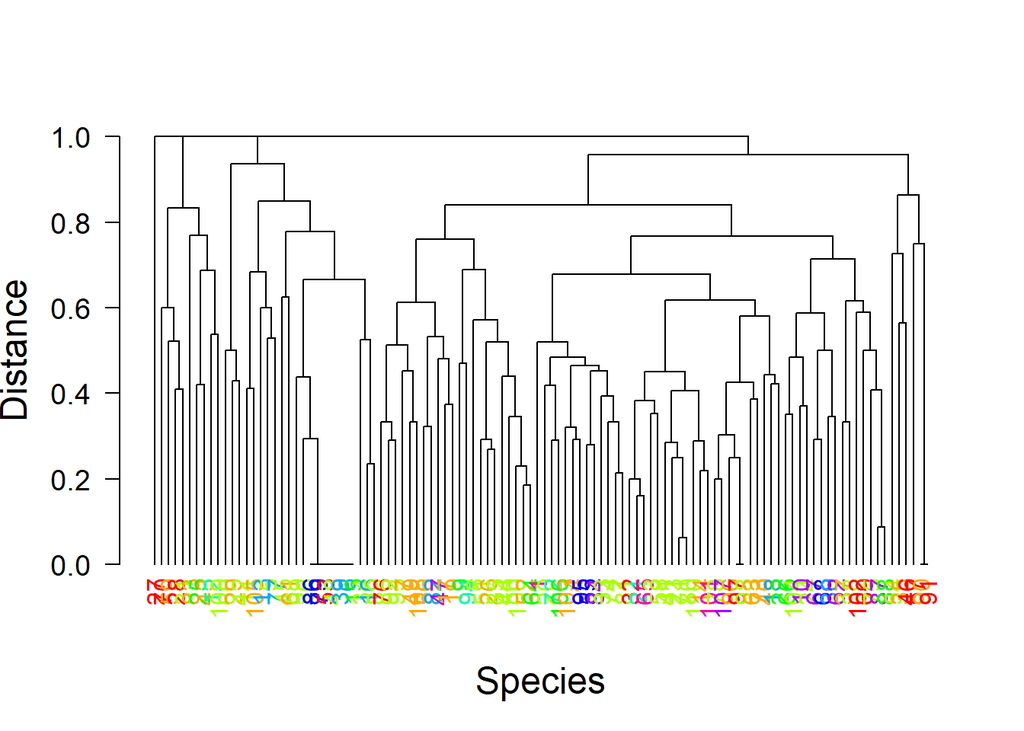

```r
# Load necessary libraries

## Make subset
subset_data_clust <- overlap_species_threats_no2 %>% select(3,12,16,17,18,19,20,21,22,23,24,25,26,27,29,30,31,33,32,34,35,36,37,38,39,40,42,41,43,44,45,46,47,48,49,50,51,52,53,54,55,56,57,58,59,60,61,62,63,64,65,66,67,68,69,70)

# Step 1: Ensure that the 'taxonomic_group' information is available
taxonomic_groups <- subset_data_clust$taxonomic_group

# Step 2: Clean the taxonomic group names by removing invalid characters (special characters)
valid_taxonomic_groups <- gsub("[^[:alnum:]_]", "-", taxonomic_groups)

# Step 3: Create a color palette for each unique taxonomic group
unique_taxa <- unique(valid_taxonomic_groups)
color_palette <- rainbow(length(unique_taxa))  # Use the rainbow color palette

# Step 4: Create a named vector of colors, mapping each taxonomic group to a specific color
taxa_colors <- setNames(color_palette, unique_taxa)

# Step 5: Perform hierarchical clustering (already done previously)
clustering <- hclust(dist, method = "complete")

# Convert hclust object to dendrogram object
dendrogram <- as.dendrogram(clustering)

# Step 6: Assign taxonomic group colors to dendrogram labels
dendrogram_colored <- dendrogram %>%
  set("labels_colors", taxa_colors[valid_taxonomic_groups])  # Assign taxonomic group colors to labels

# Step 7: Plot the dendrogram and keep species names
plot(dendrogram_colored,
     xlab = "Species",
     ylab = "Distance",
     cex.axis = 1.2,    # Increase size of Y-axis text (ticks)
     cex.lab = 1.5,     # Increase size of Y-axis label and X-axis label
     cex.main = 1.5,    # Increase size of the main title
     las = 2)         # Ensure labels are not cut off and aligned properly

# Add species names to the dendrogram (ensure they are part of the dendrogram)
# The species names are usually in the row names of the original dataset
labels(dendrogram_colored) <- subset_data_clust$common_name
# Step 8: Adjusting the X-axis labels
# Move X-axis label lower using mtext()
mtext("Species", side = 1, line = 30, cex = 1.5)  # side = 1 is for X-axis
```

```r
library(tidyverse)
library(sf)
library(terra)
library(tidyterra)
```

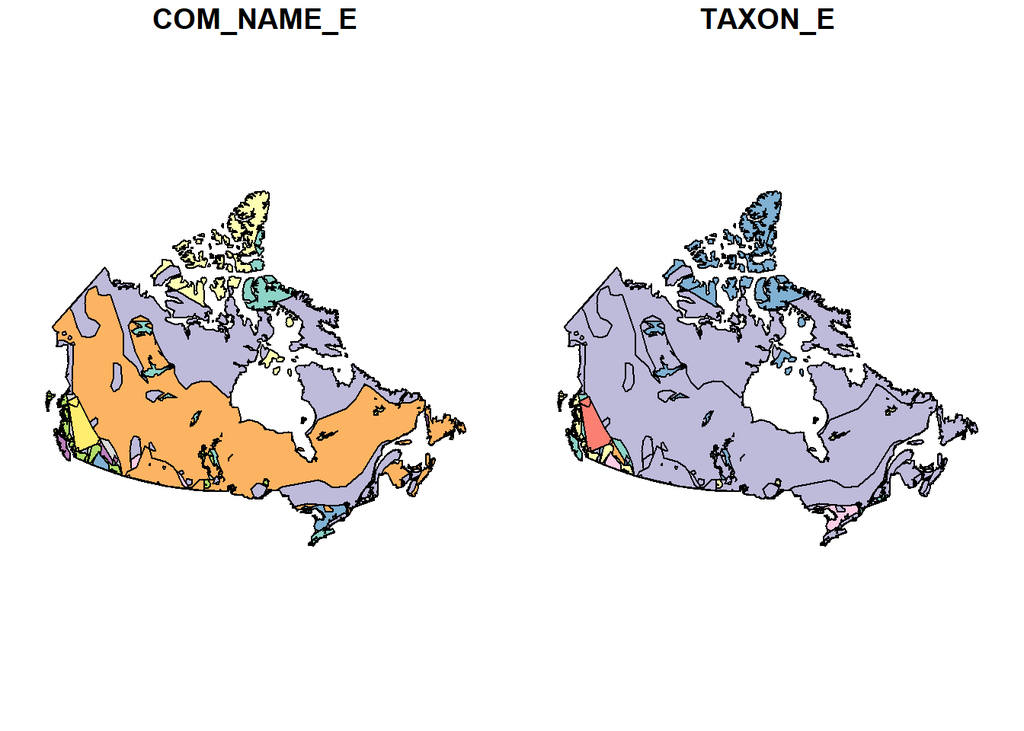

```r
### patchwork allows you to arrange plots in a grid
library(patchwork)
library(ggpattern)
sar_canada <- read_sf("Spatial_values/SpeciesAtRiskRangeMapEx_Clip_Canada.shp") %>%
  st_transform(st_crs(3978))
sar_other <- read_sf("Spatial_values/Sar_ebar_merge_dissolve_Clip.shp") %>%
  rename(COM_NAME_E = global_com) %>%
  mutate(TAXON_E = c("Lichens", "Vascular Plants", "Arthropods", "Reptiles",
                     "Birds", "Reptiles", "Molluscs", "Molluscs", "Vascular Plants",
                     "Molluscs", "Molluscs", "Amphibians", "Lichens", "Arthropods")) %>%
  st_transform(st_crs(3978))
sar_combine <- sar_canada %>%
  bind_rows(sar_other) %>%
  select(COM_NAME_E, TAXON_E) %>%
  st_simplify(dTolerance = 10000)
plot(sar_combine)
```

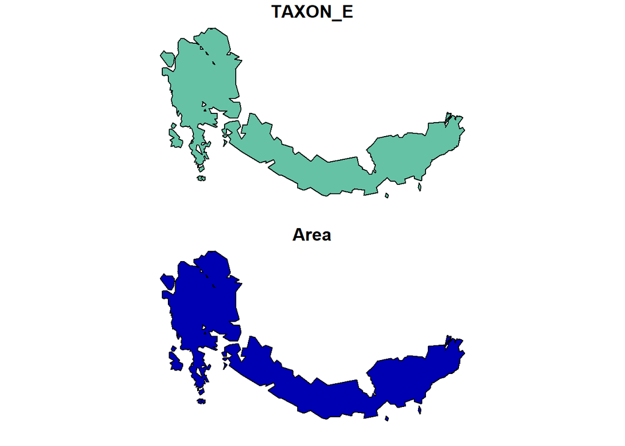

```r
caribou_range <- read_sf("Spatial_values/Woodland_caribou_dissol_Clip.shp") %>%
  st_transform(st_crs(3978)) %>%
  st_simplify(dTolerance = 10000)
plot(caribou_range)
```

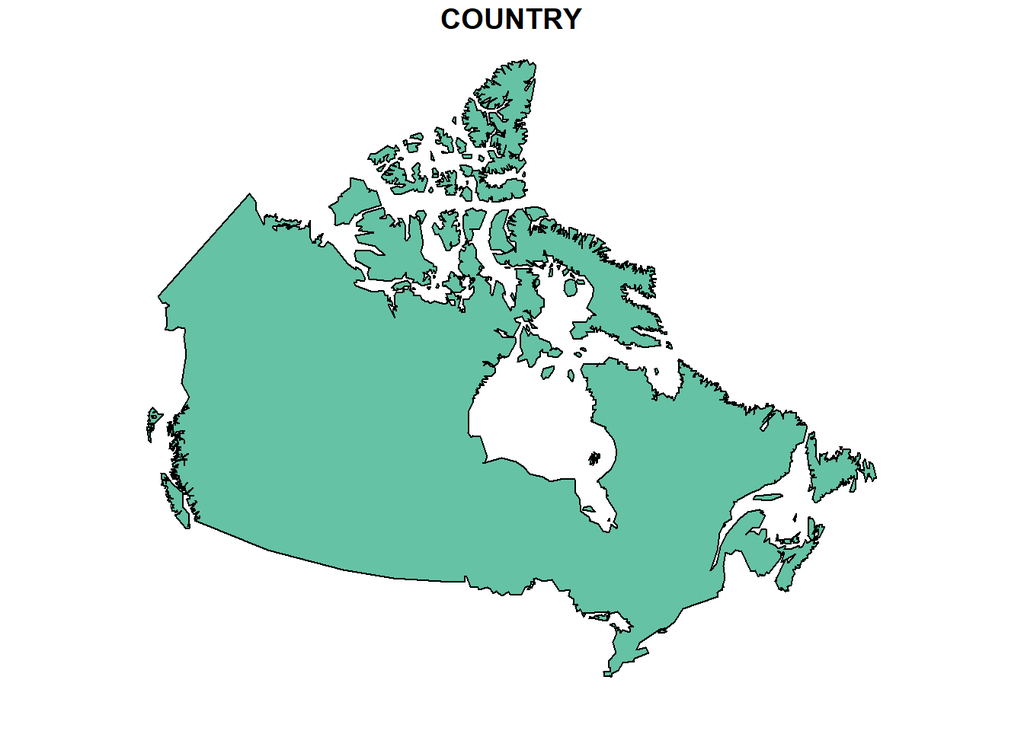

```r
canada_bound <- read_sf("Spatial_values/Caanada_w_provinces_Dissolve.shp") %>%
  st_simplify(dTolerance = 10000) %>%
  st_transform(st_crs(3978))
plot(canada_bound)
```

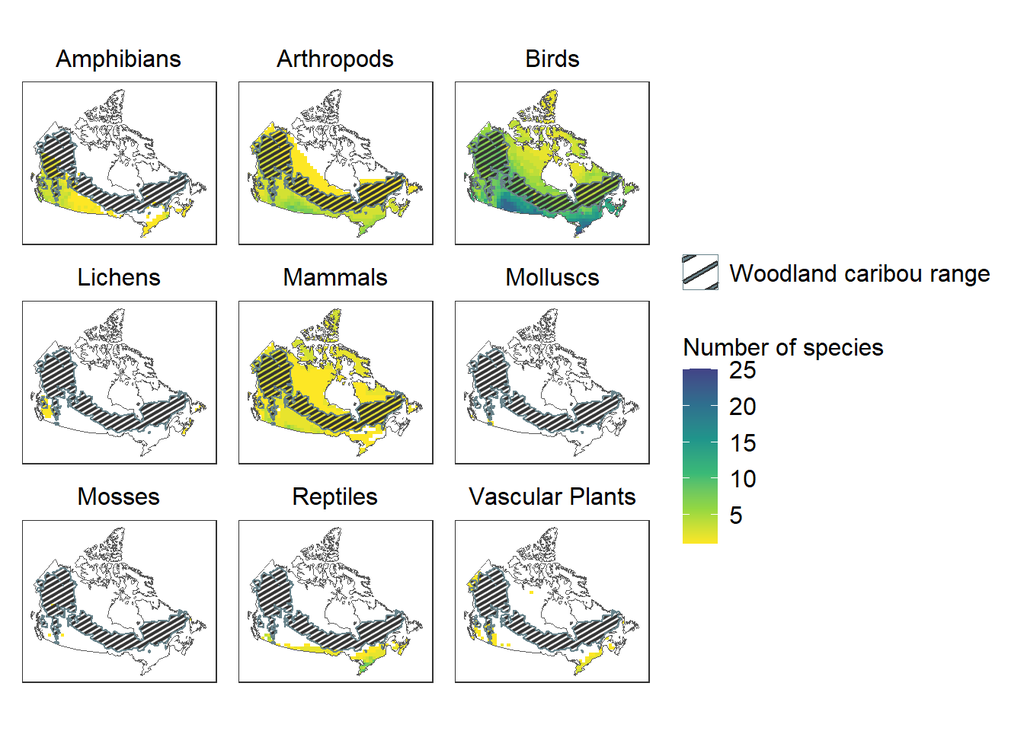

```r
taxon_counts <- summary(factor(sar_combine$TAXON_E))

sar_boundary <- st_bbox(sar_combine) %>%
  st_as_sfc()

sar_boundary_vect <- sar_boundary %>%
  vect()

### Invert canada map to mask the rasters
inv_canada <- st_difference(sar_boundary, st_union(canada_bound))

temp_rast <- rast(sar_boundary_vect, res = 100000)


### create rasters for each taxon

make_sar_raster <- function(range_polys, taxon, raster_template){
  raster <- range_polys %>%
    filter(TAXON_E == taxon) %>%
    vect() %>%
    rasterize(raster_template, fun = "count") %>%
    mask(canada_bound)
}

amphibs <- make_sar_raster(sar_combine, "Amphibians", temp_rast)
arthro <- make_sar_raster(sar_combine, "Arthropods", temp_rast)
birds <- make_sar_raster(sar_combine, "Birds", temp_rast)
lichens <- make_sar_raster(sar_combine, "Lichens", temp_rast)
mammals <- make_sar_raster(sar_combine, "Mammals", temp_rast)
mollus <- make_sar_raster(sar_combine, "Molluscs", temp_rast)
moss <- make_sar_raster(sar_combine, "Mosses", temp_rast)
repts <- make_sar_raster(sar_combine, "Reptiles", temp_rast)
plants <- make_sar_raster(sar_combine, "Vascular Plants", temp_rast)

create_raster_plot <- function(raster, taxon){
  plot <- ggplot(data = canada_bound) +
    geom_spatraster(data = raster) +
    geom_sf(data = inv_canada, fill = "white", colour = NA) +
    geom_sf(fill = NA) +
    geom_sf_pattern(data = caribou_range, aes(colour = "Woodland caribou range"),
            fill = NA, linewidth = 0.5,
            pattern = "stripe", pattern_fill = "lightblue4",
            pattern_spacing = 0.03) +
    scale_colour_manual(values = "lightblue4") +
    labs(colour = "") +
    scale_fill_viridis_c(na.value = "transparent",
                        limits = c(1,25),
                        direction = -1,
                        begin = 0.2) +
    labs(fill = "Number of species", title = taxon) +
    theme_bw() +
    theme(panel.background = element_rect(fill = "white"),
          axis.ticks = element_blank(),
          axis.text = element_blank(),
          panel.grid = element_blank(),
          legend.text = element_text(size = 12),
          legend.title = element_text(size = 12),
          plot.title = element_text(size = 12, hjust = 0.5))
}

amphibs_plot <- create_raster_plot(amphibs, "Amphibians")
arthro_plot <- create_raster_plot(arthro, "Arthropods")
birds_plot <- create_raster_plot(birds, "Birds")
lichens_plot <- create_raster_plot(lichens, "Lichens")
mammals_plot <- create_raster_plot(mammals, "Mammals")
mollus_plot <- create_raster_plot(mollus, "Molluscs")
moss_plot <- create_raster_plot(moss, "Mosses")
repts_plot <- create_raster_plot(repts, "Reptiles")
plants_plot <- create_raster_plot(plants, "Vascular Plants")

amphibs_plot + arthro_plot + birds_plot + lichens_plot + mammals_plot +
  mollus_plot + moss_plot + repts_plot + plants_plot +
  plot_layout(ncol = 3,
              nrow = 3,
              guides = "collect"
              )
```

```r
ggsave("taxon_distribution_map.pdf", width = 10, height = 9)
```